# Biodiversity

This is my 3rd portfolio project. **My main goal** is to get as much as possible for given data. Data are provided by Codecademy.

## Imports

```python
#modules
import numpy as np
import pandas as pd
import matplotlib.pyplot as plt
import seaborn as sns
```

```python
#data
observ = pd.read_csv("observations.csv")
spec = pd.read_csv("species_info.csv")
```

**Comentary:** *Here I have imported all necessary modules and data (it is something like when artist is preparing all tools and equipments before he or she starts with its art.*

## Cleaning

```python
observ.head()
```

|  | scientific_name | park_name | observations |
| --- | --- | --- | --- |
| 0 | Vicia benghalensis | Great Smoky Mountains National Park | 68 |
| 1 | Neovison vison | Great Smoky Mountains National Park | 77 |
| 2 | Prunus subcordata | Yosemite National Park | 138 |
| 3 | Abutilon theophrasti | Bryce National Park | 84 |
| 4 | Githopsis specularioides | Great Smoky Mountains National Park | 85 |

```python
observ.dtypes
```

```
scientific_name    object
park_name          object
observations        int64
dtype: object
```

```python
spec.head()
```

|  | category | scientific_name | common_names | conservation_status |
| --- | --- | --- | --- | --- |
| 0 | Mammal | Clethrionomys gapperi gapperi | Gapper's Red-Backed Vole | NaN |
| 1 | Mammal | Bos bison | American Bison, Bison | NaN |
| 2 | Mammal | Bos taurus | Aurochs, Aurochs, Domestic Cattle (Feral), Dom... | NaN |
| 3 | Mammal | Ovis aries | Domestic Sheep, Mouflon, Red Sheep, Sheep (Feral) | NaN |
| 4 | Mammal | Cervus elaphus | Wapiti Or Elk | NaN |

```python
spec.dtypes
```

```
category               object
scientific_name        object
common_names           object
conservation_status    object
dtype: object
```

**Comentary:** *Data seems clean and ready for use. No adjustments are needed.*

## Analysing

### Observation

```python
observ.head()
```

|  | scientific_name | park_name | observations |
| --- | --- | --- | --- |
| 0 | Vicia benghalensis | Great Smoky Mountains National Park | 68 |
| 1 | Neovison vison | Great Smoky Mountains National Park | 77 |
| 2 | Prunus subcordata | Yosemite National Park | 138 |
| 3 | Abutilon theophrasti | Bryce National Park | 84 |
| 4 | Githopsis specularioides | Great Smoky Mountains National Park | 85 |

#### Distribution of spicies and observations

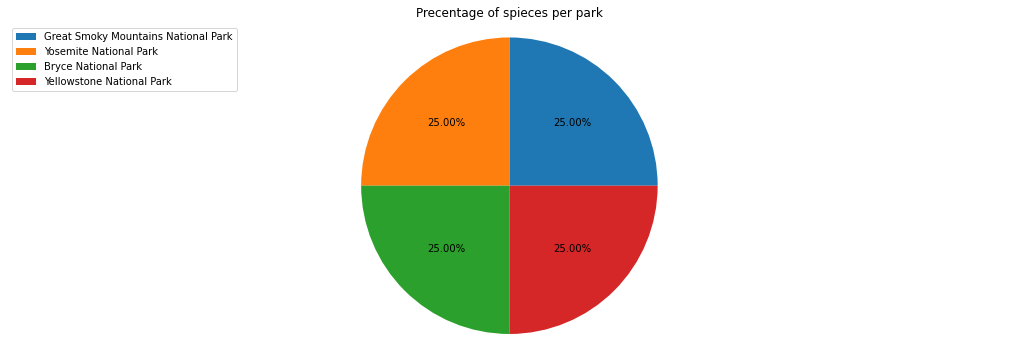

```python
#creating chart to show distribution of species between parks

#table1
precentage_observ= list(observ.park_name.value_counts() / len(observ))

#chart
plt.figure(figsize=(18, 6))
plt.pie(precentage_observ, autopct= "%0.2f%%") # autopct will make two decimals with %
plt.axis("equal") # to make it look normal
plt.legend(list(observ.park_name.unique()), loc=2)
plt.title("Precentage of spieces per park")
plt.savefig("spieces_per_park.png")
plt.show()
```

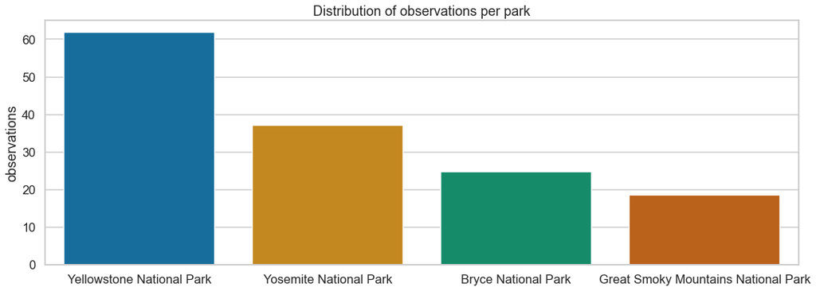

```python
#table 2
observ_total = len(observ)
observ_park = observ.groupby("park_name").observations.sum().sort_values(ascending=False)
observ_park_prec = observ.groupby("park_name").observations.sum().sort_values(ascending=False)/observ_total

#chart 2
sns.set_theme(context= "talk", style= "whitegrid", palette= "colorblind", font_scale= 1)
plt.figure(figsize=(18, 6))
sns.barplot(x=["Yellowstone National Park", "Yosemite National Park", "Bryce National Park", "Great Smoky Mountains National Park"], y= observ_park_prec)
plt.title("Distribution of observations per park")
plt.savefig("observations_per_park.png")
```

**Comentary:** *It seems like that if you want to see a animal you should go to Yellowstone which has over 40 % of all observations.*

#### Most seen spieces

```python
# creating search function
def most_seen_animal(df):
    # first benchamrk
    animal = df.iloc[0]
    name_animal_benchmark = animal.scientific_name
    observations_benchmark = animal.observations
    #comparing with benchmark
    for i in range(len(df)):
        animal = df.iloc[i]
        name_animal = animal.scientific_name
        observations = animal.observations
        if observations > observations_benchmark:
            name_animal_benchmark= name_animal
            observations_benchmark = observations

    #finding common_name
    for x in range(len(spec)):
        animal_spec = spec.iloc[x]
        scientific_name = animal_spec.scientific_name
        if scientific_name == name_animal_benchmark:
            name_animal_benchmark = animal_spec.common_names
            category = animal_spec.category
            break

    #returning values
    return name_animal_benchmark, observations_benchmark, category
```

##### In park

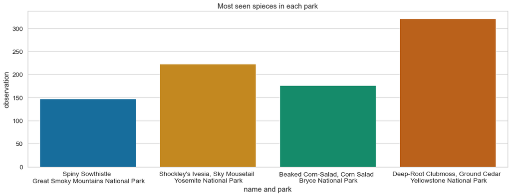

```python
# yellowstone
yellowstone = observ[observ.park_name=="Yellowstone National Park"].reset_index(drop=True)
yellowstone_animal = list(most_seen_animal(yellowstone))

# smoky mountains
smoky_mountains = observ[observ.park_name=='Great Smoky Mountains National Park'].reset_index(drop=True)
smoky_mountains_animal= list(most_seen_animal(smoky_mountains))

# yosemite
yosemite = observ[observ.park_name=="Yosemite National Park"].reset_index(drop=True)
yosemite_animal = list(most_seen_animal(yosemite))

#bryce
bryce = observ[observ.park_name=="Bryce National Park"].reset_index(drop=True)
bryce_animal= list(most_seen_animal(bryce))

#creating_df
    #separate list
animals= [smoky_mountains_animal, yosemite_animal, bryce_animal, yellowstone_animal]
animals_names = [x[0] for x in animals]
animals_observations = [x[1] for x in animals]
animals_category = [x[2] for x in animals]
parks = list(observ.park_name.unique())
        #special list for chart
name_park = list(zip(animals_names, parks))
name_park = ["{} \n {}".format(x[0], x[1]) for x in name_park]

    #creating dictonaries
animals_dict = {}
animals_dict["park"] = parks
animals_dict["name"]= animals_names
animals_dict["observation"]= animals_observations
animals_dict["category"]= animals_category
animals_dict["name and park"]= name_park
    #creating df finally
most_seen_animal_df = pd.DataFrame(data= animals_dict)

#creating chart
sns.set_theme(context= "notebook", style= "whitegrid", palette= "colorblind", font_scale= 1.25)
plt.figure(figsize=(18, 6))
plt.title("Most seen spieces in each park")
sns.barplot(data= most_seen_animal_df, x= "name and park", y="observation")
```

**Comentary:** *These are the most observed species in each park. It is a plant for all parks.*

##### In data

```python
#finding top 10
observ_sort = observ.sort_values(by="observations", ascending= False).reset_index(drop=True)
observ_top10 = observ_sort.iloc[:10]
observ_top100 = observ_sort.iloc[:100]


#adding extra informations
scientific_name_list = list(observ_top10.scientific_name)
category_list = []
common_names_list = []
for o in range(len(scientific_name_list)):
    scientific_name = scientific_name_list[o]
    for w in range(len(spec)):
        animal_spec = spec.iloc[w]
        scientific_name_spec = animal_spec.scientific_name
        if scientific_name_spec == scientific_name:
            category = animal_spec.category
            common_names = animal_spec.common_names
            category_list.append(category)
            common_names_list.append(common_names)
            break

#adding extra informations to 100
scientific_name_list = list(observ_top100.scientific_name)
category_list_100 = []
common_names_list_100 = []
for o in range(len(scientific_name_list)):
    scientific_name = scientific_name_list[o]
    for w in range(len(spec)):
        animal_spec = spec.iloc[w]
        scientific_name_spec = animal_spec.scientific_name
        if scientific_name_spec == scientific_name:
            category = animal_spec.category
            common_names = animal_spec.common_names
            category_list_100.append(category)
            common_names_list_100.append(common_names)
            break

#putting them to df
observ_top10["category"]= category_list
observ_top10["name"]= common_names_list
observ_top100["category"]= category_list_100
observ_top100["name"]= common_names_list_100


#intresting chart
observ_groupby_category = observ_top100.groupby("category").name.count().reset_index().sort_values(by= "name", ascending= False)
```

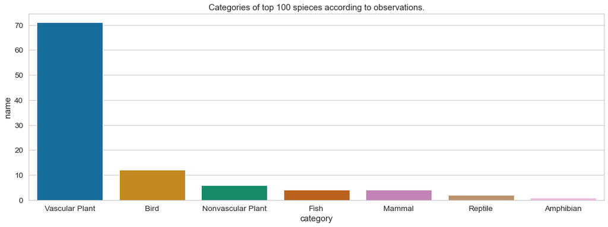

```python
plt.figure(figsize=(18, 6))
plt.title("Categories of top 100 spieces according to observations.")
sns.barplot(data= observ_groupby_category, x="category", y="name")
plt.savefig("top_100_spices_categories")
```

**Comentary:** *It seems like the most observed category through all data is Vascular Plant. From top 100 (according to observations) it is Vascular Plant in more than 70 examples. Bird is the next most common category, but it has only around 10 among top 100 (according to observations).*

### Where go to see....

#### Category --> park

```python
def groupby_category(df):
#finding categories
    df= df.merge(spec, on= "scientific_name", how="inner")
#grouping by it
    group = df.groupby("category").observations.sum().reset_index()
    total_observ = observ.observations.sum()
    #group = group.observations.apply(lambda x: x)
    return group
```

```python
yellowstone_groups= groupby_category(yellowstone)
smoky_mountains_groups= groupby_category(smoky_mountains)
yosemite_groups = groupby_category(yosemite)
bryce_groups = groupby_category(bryce)

yellowstone_groups
```

|  | category | observations |
| --- | --- | --- |
| 0 | Amphibian | 19937 |
| 1 | Bird | 144300 |
| 2 | Fish | 31459 |
| 3 | Mammal | 70701 |
| 4 | Nonvascular Plant | 83021 |
| 5 | Reptile | 20061 |
| 6 | Vascular Plant | 1218162 |

```python
#creating df + chart
    #lists
category_list = ["Amphibian", "Bird", "Fish", "Mammal", "Nonvascular Plant","Reptile", "Vascular Plant"]
yellowstone_list = list(yellowstone_groups.observations)
smoky_list = list(smoky_mountains_groups.observations)
yosemite_list = list(yosemite_groups.observations)
bryce_list= list(bryce_groups.observations)
park1 = ["Yellowstone" for x in range(7)]
park2 = ["Smoky mountains" for x in range(7)]
park3 = ["Yosemite" for x in range(7)]
park4 = ["Bryce" for x in range(7)]
park = park1 + park2 + park3 + park4
    #dict
groups_dict= {}
groups_dict["category"] = category_list + category_list + category_list + category_list
groups_dict["observations"]= yellowstone_list + smoky_list +yosemite_list +bryce_list
groups_dict["National park"] = park
#groups_dict["park"]
    #df
groups_df = pd.DataFrame(data=groups_dict)
```

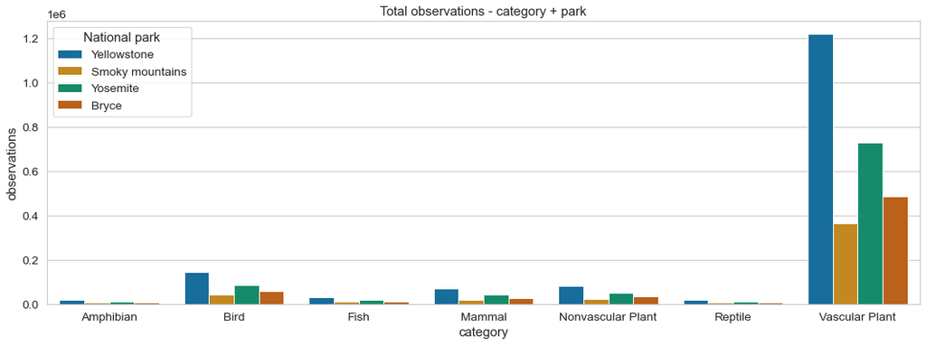

```python
plt.clf()
plt.figure(figsize=(18, 6))
plt.title("Total observations - category + park")
sns.barplot(data= groups_df, x="category", y="observations", hue="National park")
plt.savefig("observations_park_categories")
```

**Comentary:** *This graph clearly demonstrate that most observed category is VAscular Plant in Yellowstone park.*

```
     category  observations    National park
0   Amphibian     44.237597      Yellowstone
7   Amphibian     13.038076  Smoky mountains
14  Amphibian     25.989616         Yosemite
21  Amphibian     16.734712            Bryce
```

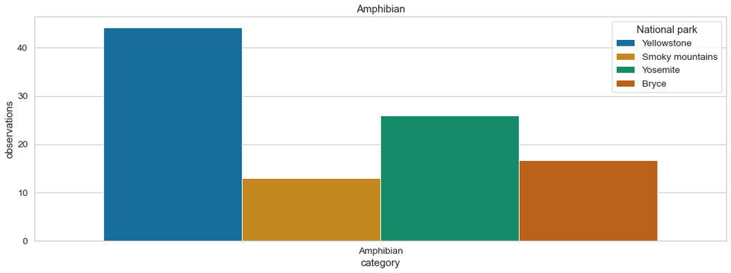

```
   category  observations    National park
1      Bird     43.415340      Yellowstone
8      Bird     12.897936  Smoky mountains
15     Bird     26.058832         Yosemite
22     Bird     17.627892            Bryce
```

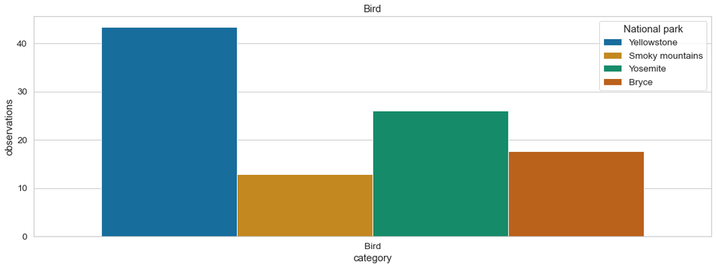

```
   category  observations    National park
2      Fish     43.153043      Yellowstone
9      Fish     13.006680  Smoky mountains
16     Fish     26.250669         Yosemite
23     Fish     17.589608            Bryce
```

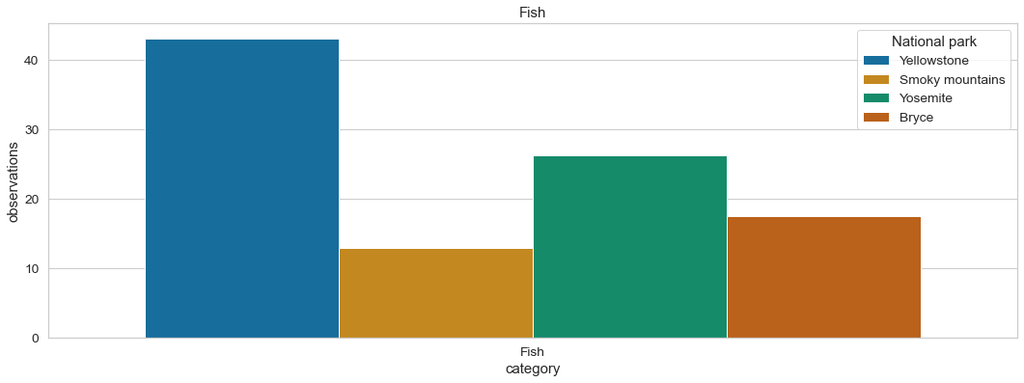

```
   category  observations    National park
3    Mammal     43.342938      Yellowstone
10   Mammal     12.908288  Smoky mountains
17   Mammal     26.074669         Yosemite
24   Mammal     17.674105            Bryce
```

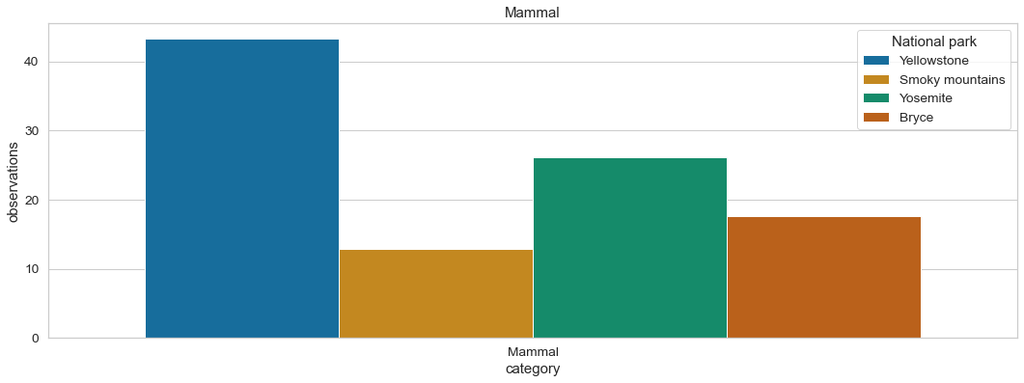

```
             category  observations    National park
4   Nonvascular Plant     43.545604      Yellowstone
11  Nonvascular Plant     13.037823  Smoky mountains
18  Nonvascular Plant     26.111837         Yosemite
25  Nonvascular Plant     17.304737            Bryce
```

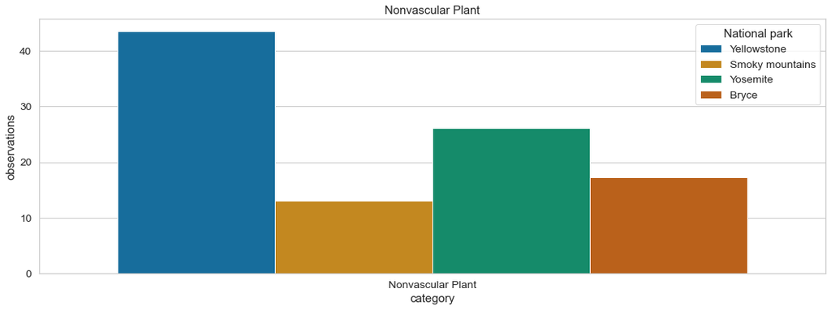

```
   category  observations    National park
5   Reptile     43.780280      Yellowstone
12  Reptile     12.747152  Smoky mountains
19  Reptile     25.705993         Yosemite
26  Reptile     17.766575            Bryce
```

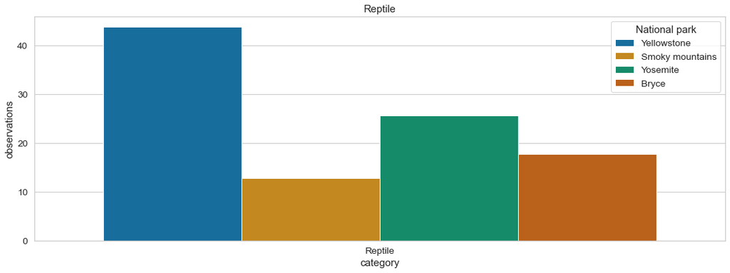

```
          category  observations    National park
6   Vascular Plant     43.578749      Yellowstone
13  Vascular Plant     13.053355  Smoky mountains
20  Vascular Plant     26.039848         Yosemite
27  Vascular Plant     17.328048            Bryce
```

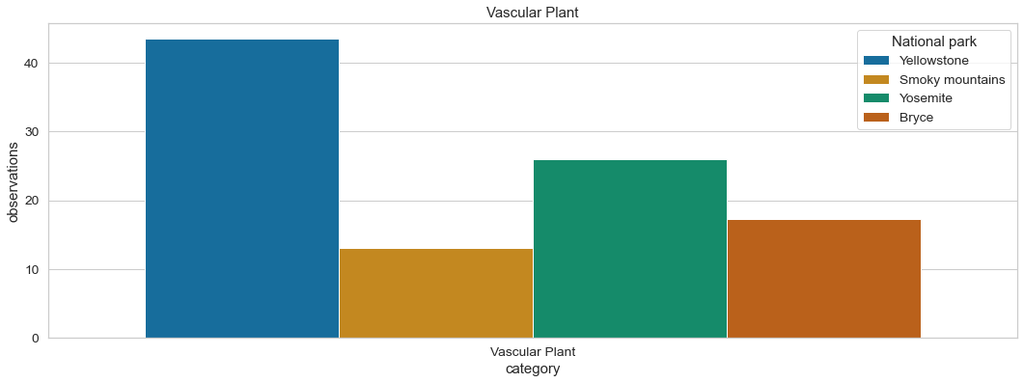

```python
for category in category_list:
    df = groups_df[groups_df.category== category]
    total_observ = df.observations.sum()
    df.observations = df.observations.apply(lambda x: x/total_observ)
    df.observations = df.observations.apply(lambda x: x * 100)
    print(df)


    plt.clf()
    plt.figure(figsize=(18, 6))
    plt.title(category)
    sns.barplot(data= df, x="category", y="observations", hue="National park")
    plt.show()
```

**Comentary:** *Graphs shows that all categories are mostly observed in Yellowstone National Park (over 40 % of observations for each category).*

## Chyba při merge -> více položek než před merge

# Best park for each spiece

```python
#getting ready df
observ_common_name= observ.merge(spec, on= "scientific_name", how="inner")
observ_common_name =  observ_common_name.drop(columns = ["conservation_status"], axis= 1)
```

```python
#creating list
unique_scientific_name= list(observ_common_name.scientific_name.unique())
best_park = []
scientific_name = []
common_names = []
category = []

for name in unique_scientific_name:
    #creating df
    spieces_df = observ_common_name[observ_common_name.scientific_name == name]
    observations_list= list(spieces_df.observations)

    #finding the best
    index= 5
    benchmark = 0
    for i in range(len(observations_list)):
        observations= observations_list[i]
        if observations > benchmark:
            benchmark = observations
            index = i

    #selecting the best
    best_park.append(spieces_df.iloc[index].park_name)
    scientific_name.append(name)

    #adding extra informations
    common_names.append(spieces_df.common_names.iloc[0])
    category.append(spieces_df.category.iloc[0])
```

```python
#creating dictonary
best_see_dict = {}
best_see_dict["scientific_name"]= scientific_name
best_see_dict["common_names"]= common_names
best_see_dict["category"]= category
best_see_dict["most_obesrvations_in"] = best_park

#creating df
most_observations_in = pd.DataFrame(data=best_see_dict)
most_observations_in.most_obesrvations_in.unique()

most_observations_in.most_obesrvations_in.value_counts()
```

```
Yellowstone National Park    5541
Name: most_obesrvations_in, dtype: int64
```

```python
most_observations_in.head()
```

|  | scientific_name | common_names | category | most_obesrvations_in |
| --- | --- | --- | --- | --- |
| 0 | Vicia benghalensis | Purple Vetch, Reddish Tufted Vetch | Vascular Plant | Yellowstone National Park |
| 1 | Neovison vison | American Mink | Mammal | Yellowstone National Park |
| 2 | Prunus subcordata | Klamath Plum | Vascular Plant | Yellowstone National Park |
| 3 | Abutilon theophrasti | Velvetleaf | Vascular Plant | Yellowstone National Park |
| 4 | Githopsis specularioides | Common Bluecup | Vascular Plant | Yellowstone National Park |

**Comentary:** *I have created a table which shows best park to go for all spiecies, but best option for each animal or flower is Yellowstone National Park, therefore isn't necessery to export table or create a chart.